# Red Wine Explorotary Data Analysis

Stanislava Taks

23 March, 2019

### Introduction

The quality of wine is influenced by proportion of chemical properties, including factors such as acidity, sugars, pH, sulfur dioxide, sulphates, alcohol, and chlorides. I explore the relationship between these and other features and also observe which factors affect the quality of wine.

# Univariate Plots Section

In this section I perform preliminary exploration of data.

```
##  [1] "X"                    "fixed.acidity"        "volatile.acidity"
##  [4] "citric.acid"          "residual.sugar"       "chlorides"
##  [7] "free.sulfur.dioxide"  "total.sulfur.dioxide" "density"
## [10] "pH"                   "sulphates"            "alcohol"
## [13] "quality"
```

The above shows the columns of the data set.

```
##   X fixed.acidity volatile.acidity citric.acid residual.sugar chlorides
## 1 1           7.4             0.70        0.00            1.9     0.076
## 2 2           7.8             0.88        0.00            2.6     0.098
## 3 3           7.8             0.76        0.04            2.3     0.092
## 4 4          11.2             0.28        0.56            1.9     0.075
## 5 5           7.4             0.70        0.00            1.9     0.076
## 6 6           7.4             0.66        0.00            1.8     0.075
##   free.sulfur.dioxide total.sulfur.dioxide density   pH sulphates alcohol
## 1                  11                   34  0.9978 3.51      0.56     9.4
## 2                  25                   67  0.9968 3.20      0.68     9.8
## 3                  15                   54  0.9970 3.26      0.65     9.8
## 4                  17                   60  0.9980 3.16      0.58     9.8
## 5                  11                   34  0.9978 3.51      0.56     9.4
## 6                  13                   40  0.9978 3.51      0.56     9.4
##   quality
## 1       5
## 2       5
## 3       5
## 4       6
## 5       5
## 6       5
```

Above are the top 6 rows, I needed to remove the extra variable X and confirmed it:

```
##   fixed.acidity volatile.acidity citric.acid residual.sugar chlorides
## 1           7.4             0.70        0.00            1.9     0.076
## 2           7.8             0.88        0.00            2.6     0.098
## 3           7.8             0.76        0.04            2.3     0.092
## 4          11.2             0.28        0.56            1.9     0.075
## 5           7.4             0.70        0.00            1.9     0.076
## 6           7.4             0.66        0.00            1.8     0.075
##   free.sulfur.dioxide total.sulfur.dioxide density   pH sulphates alcohol
## 1                  11                   34  0.9978 3.51      0.56     9.4
## 2                  25                   67  0.9968 3.20      0.68     9.8
## 3                  15                   54  0.9970 3.26      0.65     9.8
## 4                  17                   60  0.9980 3.16      0.58     9.8
## 5                  11                   34  0.9978 3.51      0.56     9.4
## 6                  13                   40  0.9978 3.51      0.56     9.4
##   quality
## 1       5
## 2       5
## 3       5
## 4       6
## 5       5
## 6       5
```

```
## [1] 1599
```

Total rows in the data set.

```
## [1] 12
```

Total columns in the data set.

#### Quality Plot

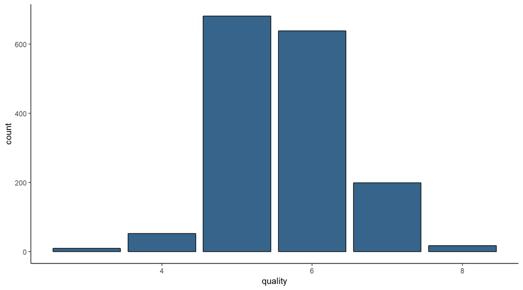

```
##    Min. 1st Qu.  Median    Mean 3rd Qu.    Max.
##   3.000   5.000   6.000   5.636   6.000   8.000
```

Mean is less than the median, the distribution is skewed left.

At this point, I will create a categorical variable called rating, which will consist of wine quality at “Below Average,” “Average,” “Above Average,” and “Superior.”

```
## [1] 5 5 5 7 7 5
```

```
## [1] Average      Average      Average      AboveAverage AboveAverage
## [6] Average
## Levels: BelowAverage Average AboveAverage Superior
```

From the sample, it is possible to see that it has been properly categorized

#### Rating

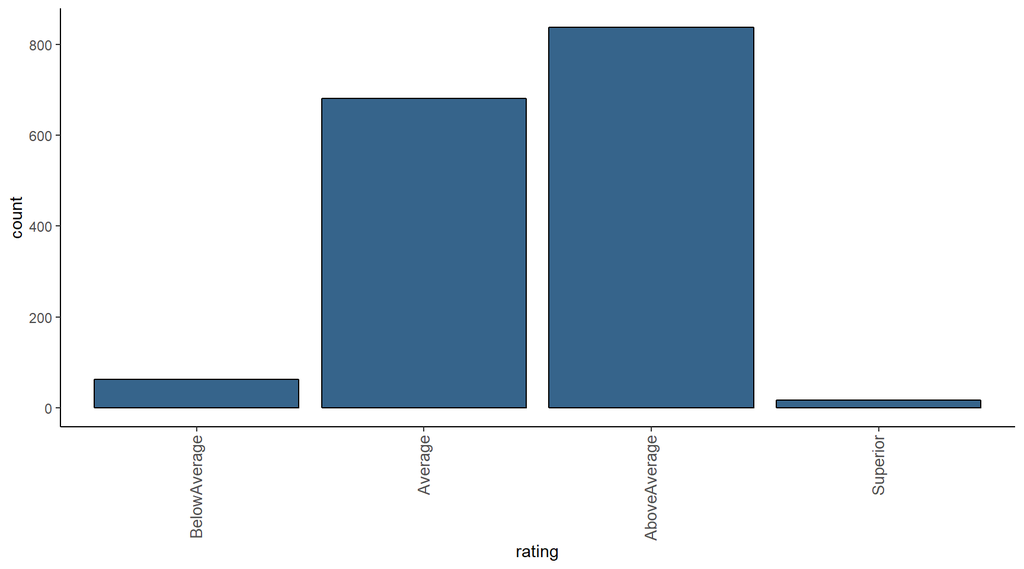

The strongest concentration of rating is in the Average and Above Average bins.

#### Fixed Acidity

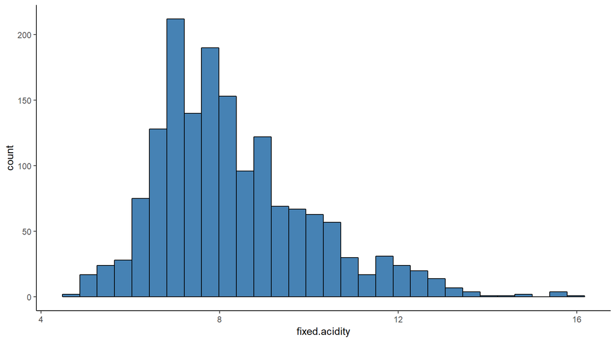

```
##    Min. 1st Qu.  Median    Mean 3rd Qu.    Max.
##    4.60    7.10    7.90    8.32    9.20   15.90
```

The mean is greater than the median, the distribution is skewed to the right.

#### Volatile Acidity

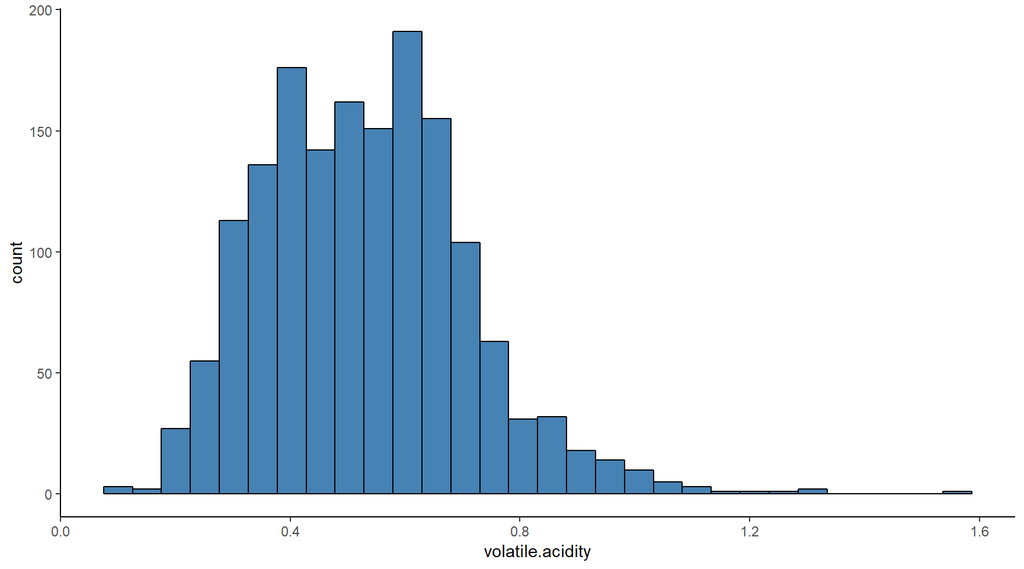

```
##    Min. 1st Qu.  Median    Mean 3rd Qu.    Max.
##  0.1200  0.3900  0.5200  0.5278  0.6400  1.5800
```

The mean is greater than the median, the distribution is skewed to the right.

#### Citric Acid

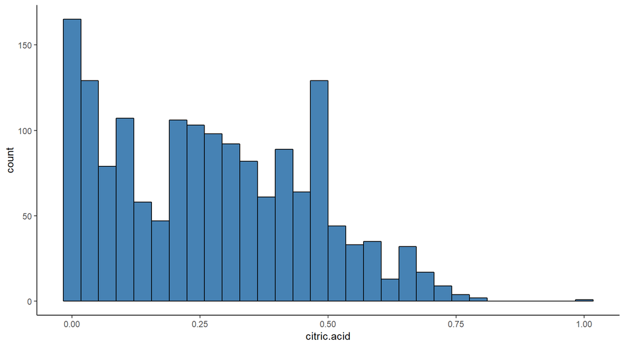

```
##    Min. 1st Qu.  Median    Mean 3rd Qu.    Max.
##   0.000   0.090   0.260   0.271   0.420   1.000
```

The mean is greater than the median, the distribution is skewed to the right.

#### Residual Sugar

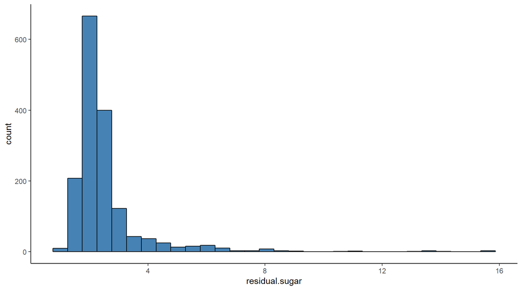

```
##    Min. 1st Qu.  Median    Mean 3rd Qu.    Max.
##   0.900   1.900   2.200   2.539   2.600  15.500
```

The mean is greater than the median, the distribution is skewed to the right.

#### Chlorides

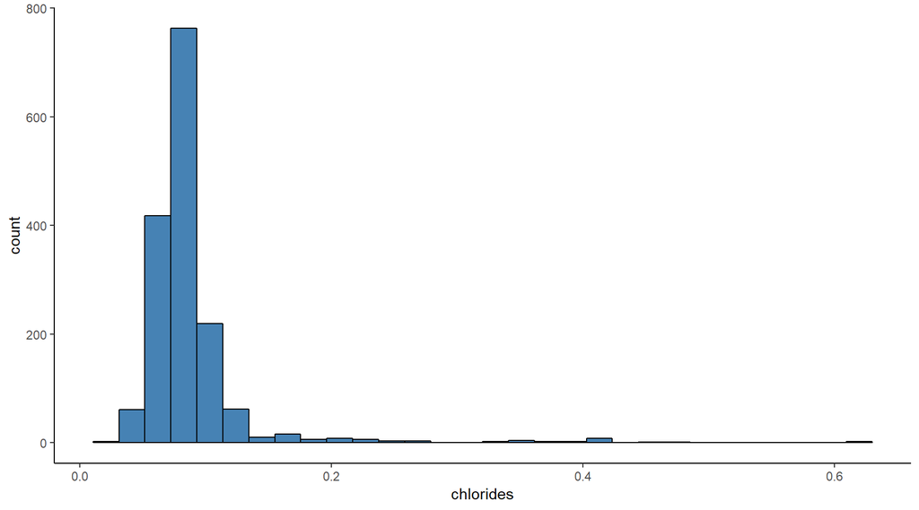

```
##    Min. 1st Qu.  Median    Mean 3rd Qu.    Max.
## 0.01200 0.07000 0.07900 0.08747 0.09000 0.61100
```

The mean is greater than the median, the distribution is skewed to the right.

#### Free Sulfur Dioxide

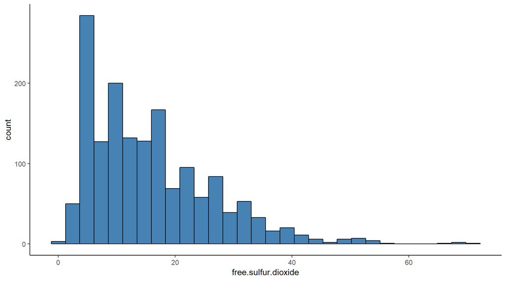

```
##    Min. 1st Qu.  Median    Mean 3rd Qu.    Max.
##    1.00    7.00   14.00   15.87   21.00   72.00
```

The mean is greater than the median, the distribution is skewed to the right.

#### Total Sulfur Dioxide

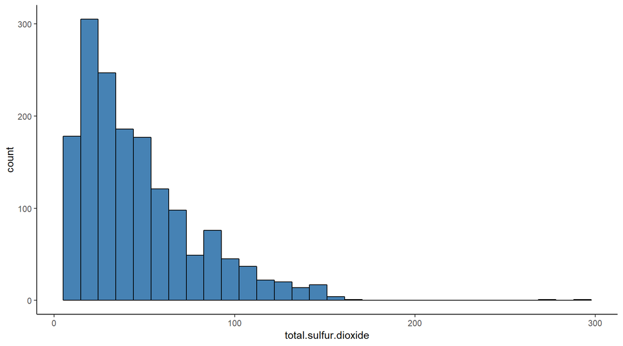

```
##    Min. 1st Qu.  Median    Mean 3rd Qu.    Max.
##    6.00   22.00   38.00   46.47   62.00  289.00
```

The mean is greater than the median, the distribution is skewed to the right.

#### Density

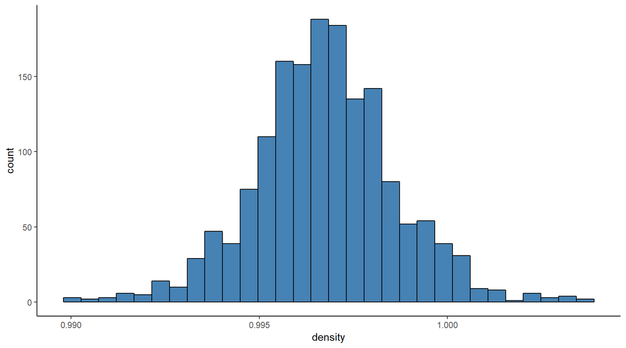

```
##    Min. 1st Qu.  Median    Mean 3rd Qu.    Max.
##  0.9901  0.9956  0.9968  0.9967  0.9978  1.0037
```

Density appears to be normally distributed.

#### pH

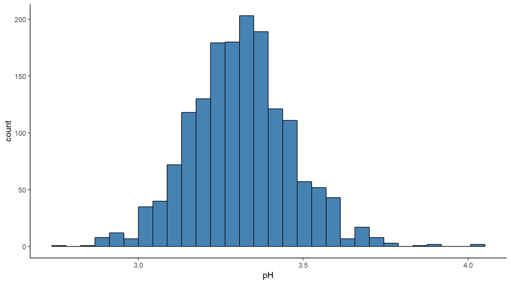

```
##    Min. 1st Qu.  Median    Mean 3rd Qu.    Max.
##   2.740   3.210   3.310   3.311   3.400   4.010
```

pH appears to be normally distributed.

#### Sulphates

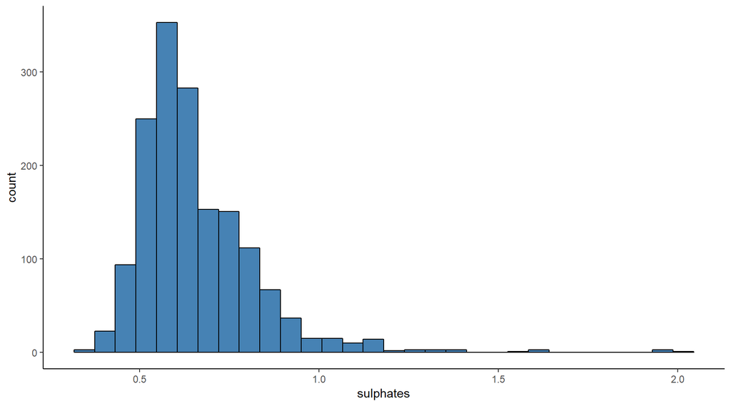

```
##    Min. 1st Qu.  Median    Mean 3rd Qu.    Max.
##  0.3300  0.5500  0.6200  0.6581  0.7300  2.0000
```

The mean is greater than the median, the distribution is skewed to the right.

#### Alcohol

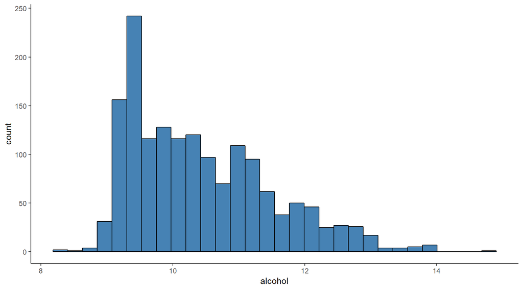

```
##    Min. 1st Qu.  Median    Mean 3rd Qu.    Max.
##    8.40    9.50   10.20   10.42   11.10   14.90
```

The mean is greater than the median, the distribution is skewed to the right.

# Univariate Analysis

### What is the structure of your dataset?

```
## 'data.frame':    1599 obs. of  12 variables:
##  $ fixed.acidity       : num  7.4 7.8 7.8 11.2 7.4 7.4 7.9 7.3 7.8 7.5 ...
##  $ volatile.acidity    : num  0.7 0.88 0.76 0.28 0.7 0.66 0.6 0.65 0.58 0.5 ...
##  $ citric.acid         : num  0 0 0.04 0.56 0 0 0.06 0 0.02 0.36 ...
##  $ residual.sugar      : num  1.9 2.6 2.3 1.9 1.9 1.8 1.6 1.2 2 6.1 ...
##  $ chlorides           : num  0.076 0.098 0.092 0.075 0.076 0.075 0.069 0.065 0.073 0.071 ...
##  $ free.sulfur.dioxide : num  11 25 15 17 11 13 15 15 9 17 ...
##  $ total.sulfur.dioxide: num  34 67 54 60 34 40 59 21 18 102 ...
##  $ density             : num  0.998 0.997 0.997 0.998 0.998 ...
##  $ pH                  : num  3.51 3.2 3.26 3.16 3.51 3.51 3.3 3.39 3.36 3.35 ...
##  $ sulphates           : num  0.56 0.68 0.65 0.58 0.56 0.56 0.46 0.47 0.57 0.8 ...
##  $ alcohol             : num  9.4 9.8 9.8 9.8 9.4 9.4 9.4 10 9.5 10.5 ...
##  $ quality             : int  5 5 5 6 5 5 5 7 7 5 ...
```

There are 1599 obs. of 12 variables.

### What is/are the main feature(s) of interest in your dataset?

I will concentrate on exploring the variables affecting quality.

### What other features in the dataset do you think will help support your investigation into your feature(s) of interest?

It is necessary to observe not only the affecting variable but also the relationships between other variables, since there may be unexpected dependancies.

### Did you create any new variables from existing variables in the dataset?

Yes. I created a categorical variable called “rating,” which ranks quality at “Below Average,” “Average,” “Above Average,” and “Superior.”

### Of the features you investigated, were there any unusual distributions? Did you perform any operations on the data to tidy, adjust, or change the form of the data? If so, why did you do this?

Just dropped the X variable because it is unecessary.

# Bivariate Plots Section

#### Quality vs. Alcohol

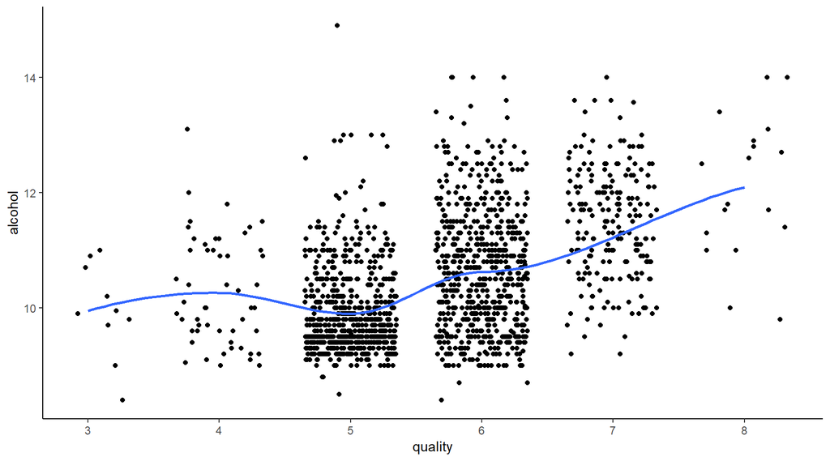

There is a visible positive relationship between alcohol and quality.

#### Quality vs. Residual Sugar

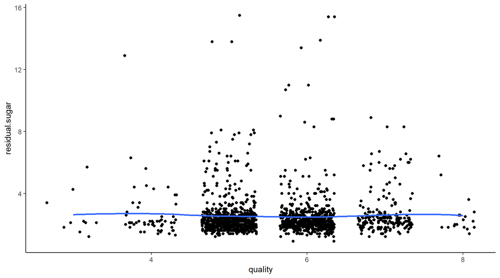

There does not appear to be much of a relationship between residual sugar and quality.

#### Quality vs. pH

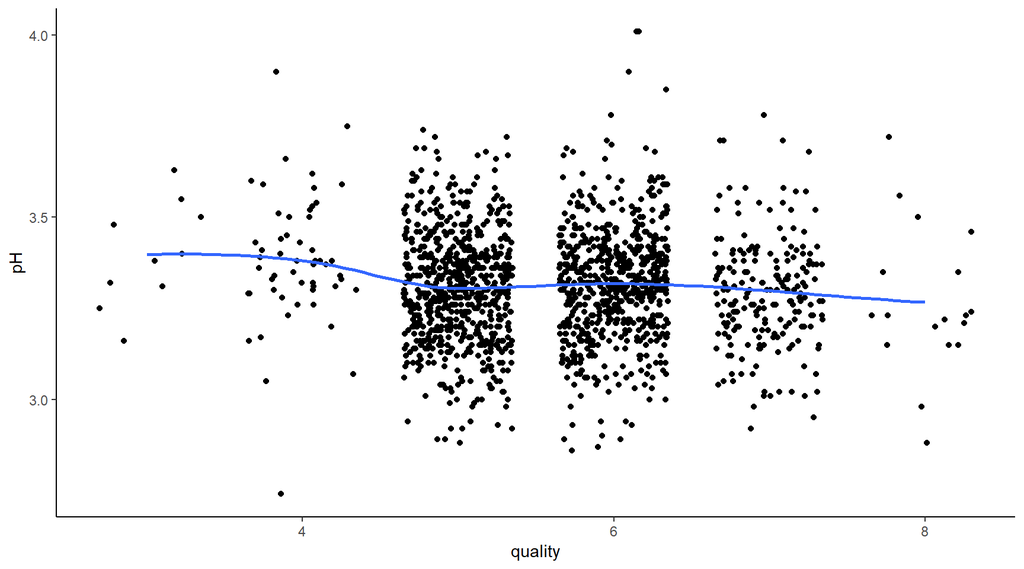

There appears to be a weak negative relationship between the level of pH and quality

#### Quality vs. Volatile Acidity

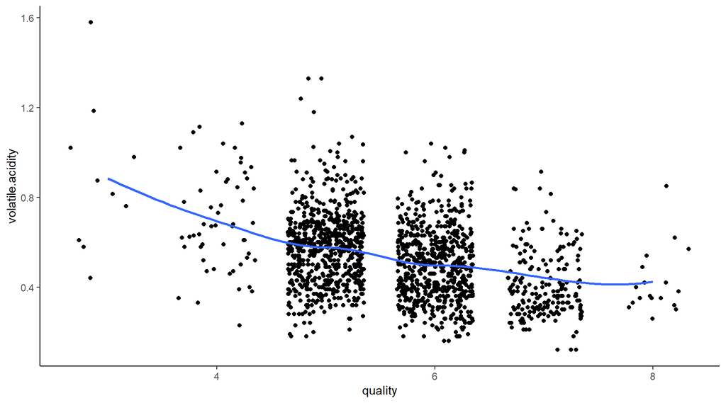

There is a visible negative relationship between volatile acidity and quality.

#### Quality vs. Sulphates

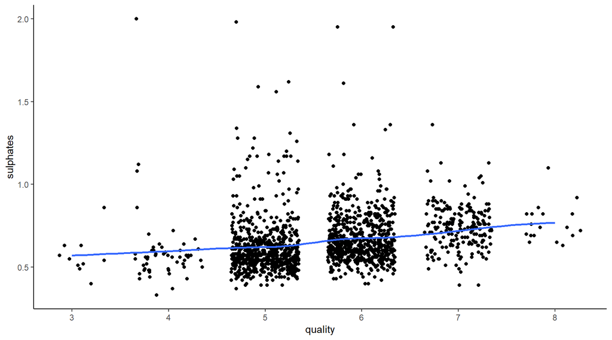

There is a weak positive correlation between sulphates and quality.

#### Quality vs. Citric Acid

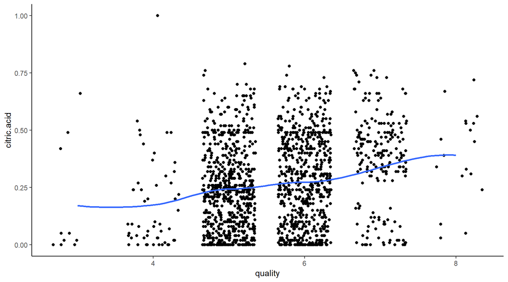

There is a weak positive relationship between citric acid and quality.

#### Correlation Matrix

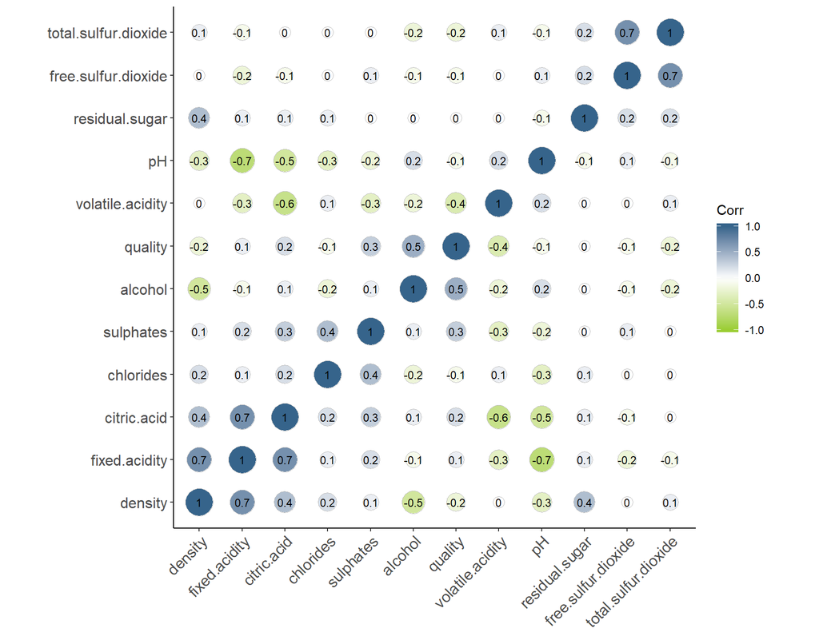

Quality had the strongest correlations with sulphates, volatile acidity, and alcohol. To more closely look into the higher correlations with quality, I will compare by rating:

#### Rating vs. Sulphates

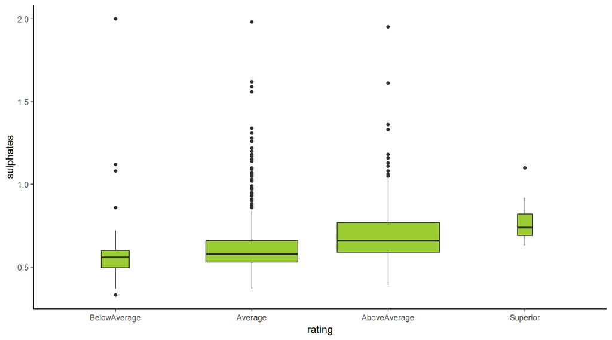

Sulphates add to the sharpness of taste and correct mineral deficiencies, the right combination seems to be more dominant in above average and superior red wines.

#### Rating vs. Alcohol

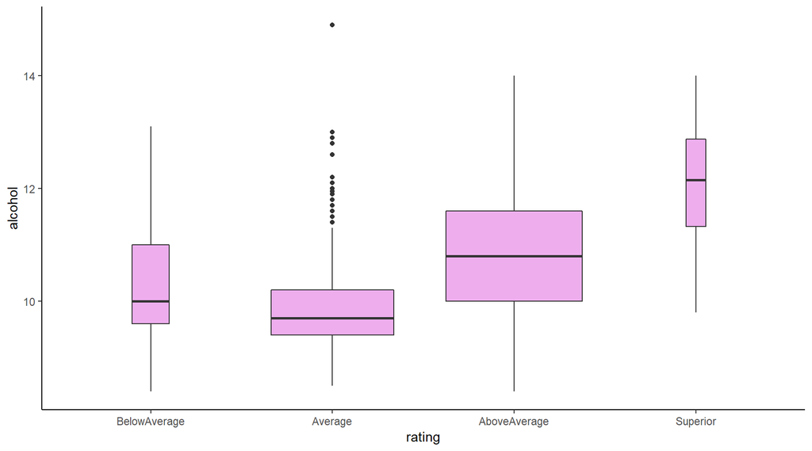

Superior and above average wines have higher concentration of alcohol.

#### Rating vs. Volatile Acidity

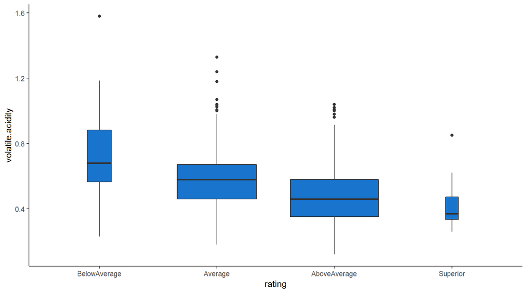

#### Fixed Acidity vs. Citric Acid

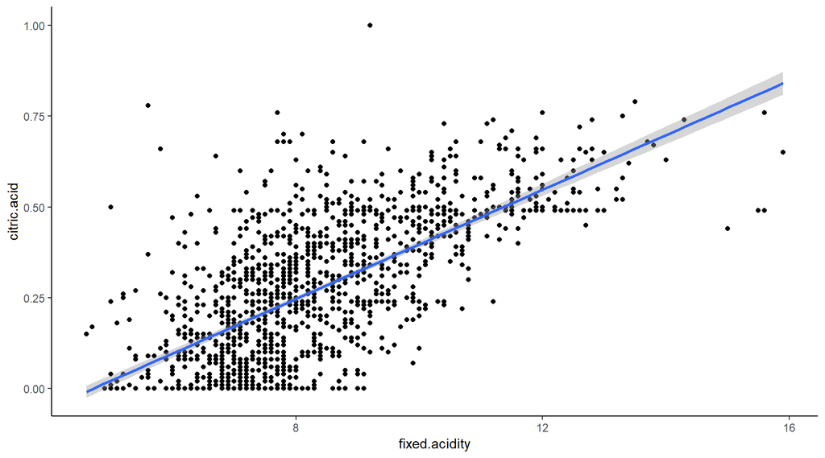

Strong positive corr=0.7.

#### Fixed Acidity vs. pH

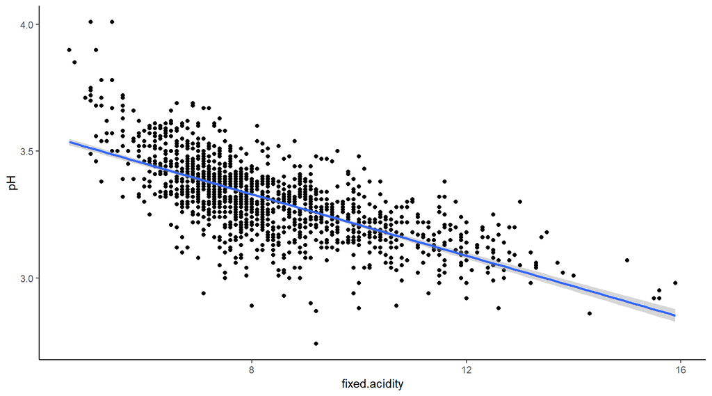

Strong negative corr=-0.7. It would be intersting to see how quality will pair to the above two relationships.

#### Correlations:

```
##                      fixed.acidity volatile.acidity citric.acid
## fixed.acidity                 1.00            -0.26        0.67
## volatile.acidity             -0.26             1.00       -0.55
## citric.acid                   0.67            -0.55        1.00
## residual.sugar                0.11             0.00        0.14
## chlorides                     0.09             0.06        0.20
## free.sulfur.dioxide          -0.15            -0.01       -0.06
## total.sulfur.dioxide         -0.11             0.08        0.04
## density                       0.67             0.02        0.36
## pH                           -0.68             0.23       -0.54
## sulphates                     0.18            -0.26        0.31
## alcohol                      -0.06            -0.20        0.11
## quality                       0.12            -0.39        0.23
##                      residual.sugar chlorides free.sulfur.dioxide
## fixed.acidity                  0.11      0.09               -0.15
## volatile.acidity               0.00      0.06               -0.01
## citric.acid                    0.14      0.20               -0.06
## residual.sugar                 1.00      0.06                0.19
## chlorides                      0.06      1.00                0.01
## free.sulfur.dioxide            0.19      0.01                1.00
## total.sulfur.dioxide           0.20      0.05                0.67
## density                        0.36      0.20               -0.02
## pH                            -0.09     -0.27                0.07
## sulphates                      0.01      0.37                0.05
## alcohol                        0.04     -0.22               -0.07
## quality                        0.01     -0.13               -0.05
##                      total.sulfur.dioxide density    pH sulphates alcohol
## fixed.acidity                       -0.11    0.67 -0.68      0.18   -0.06
## volatile.acidity                     0.08    0.02  0.23     -0.26   -0.20
## citric.acid                          0.04    0.36 -0.54      0.31    0.11
## residual.sugar                       0.20    0.36 -0.09      0.01    0.04
## chlorides                            0.05    0.20 -0.27      0.37   -0.22
## free.sulfur.dioxide                  0.67   -0.02  0.07      0.05   -0.07
## total.sulfur.dioxide                 1.00    0.07 -0.07      0.04   -0.21
## density                              0.07    1.00 -0.34      0.15   -0.50
## pH                                  -0.07   -0.34  1.00     -0.20    0.21
## sulphates                            0.04    0.15 -0.20      1.00    0.09
## alcohol                             -0.21   -0.50  0.21      0.09    1.00
## quality                             -0.19   -0.17 -0.06      0.25    0.48
##                      quality
## fixed.acidity           0.12
## volatile.acidity       -0.39
## citric.acid             0.23
## residual.sugar          0.01
## chlorides              -0.13
## free.sulfur.dioxide    -0.05
## total.sulfur.dioxide   -0.19
## density                -0.17
## pH                     -0.06
## sulphates               0.25
## alcohol                 0.48
## quality                 1.00
```

# Bivariate Analysis

### Did you observe any interesting relationships between the other features (not the main feature(s) of interest)?

It was interesting that the two highest correlations are between fixed acidity and citric acid, as well as with pH and fixed acidity. Will be interesting to see how they tie to quality.

### What was the strongest relationship you found?

The highest relationships were between fixed acidity and citric acid, as well as with pH and fixed acidity, I will look into these closer. But, since I am primarily concerned with quality, the most important strongest relationships are between quality and alcohol (corr=0.5), sulphates (corr=0.3), and volatile acidity (corr=-0.4).

# Multivariate Plots Section

#### Fixed Acidity and pH by Rating

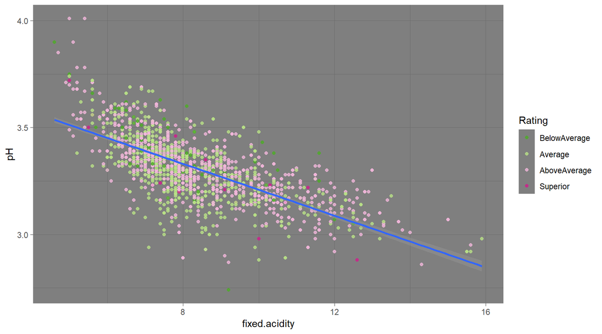

#### Fixed Aciditiy and Citric Acid by Rating

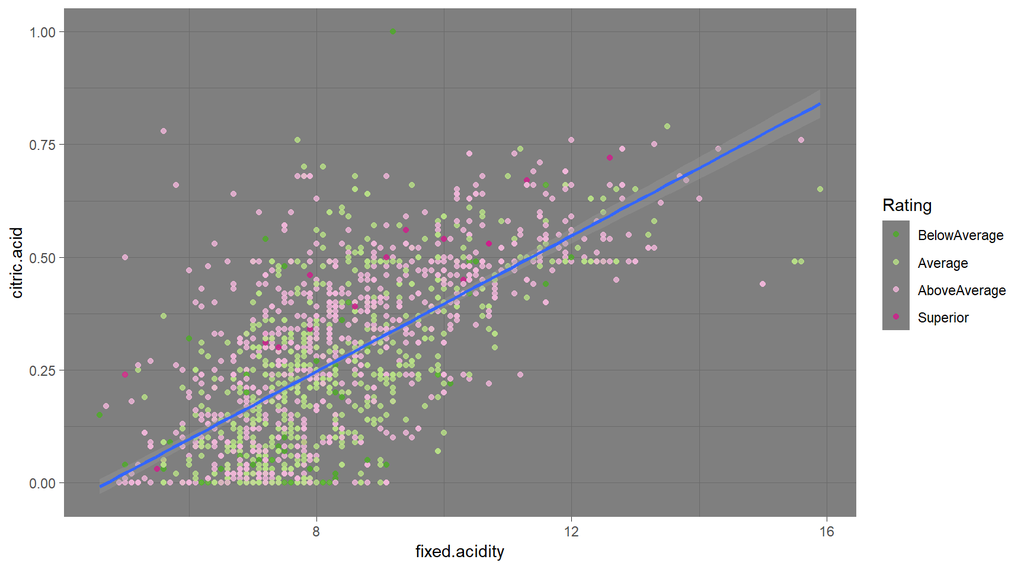

When on their own, citric acid and fixed acidity (corr=0.7) and pH and fixed acidity (corr=-0.7) show a strong positive and negative correlation, but there does not seem to be any specific clustering of rating.

#### Sulphates vs. Alcohol with Rating Ellipses

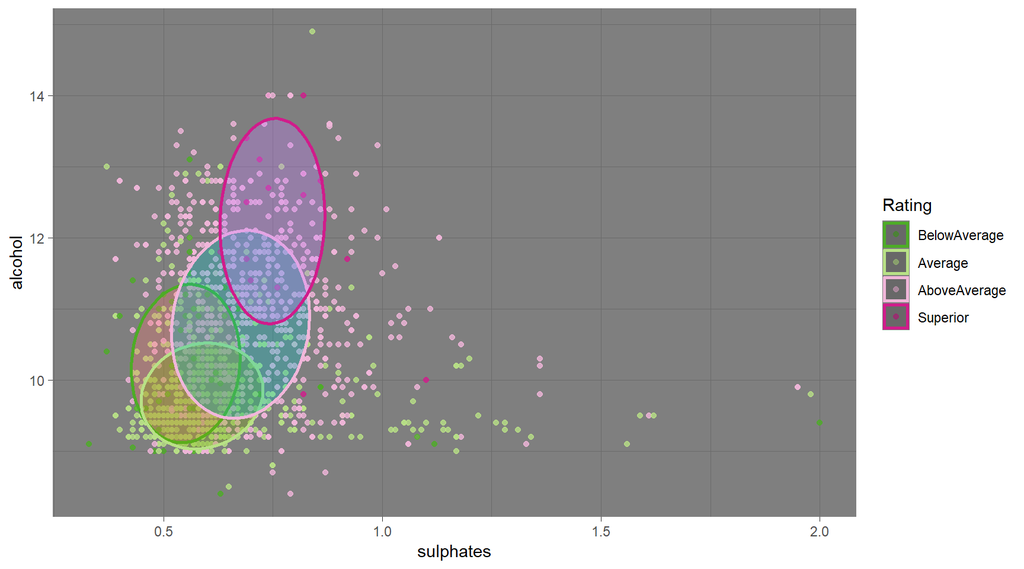

#### Volatile Acidity vs. Alcohol with Rating Ellipses

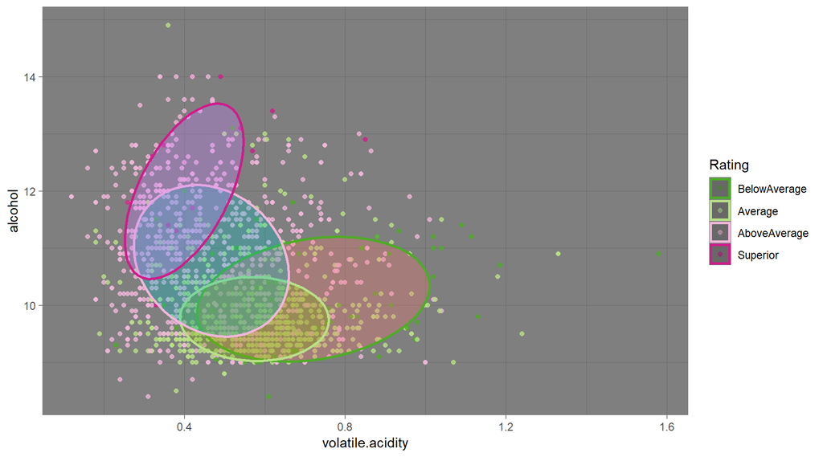

The ellipses capture the below average and superior distributions especially well. The positions of the ellipses make complete sense where higher alcohol percentage and a specific concentration of sulfates are associated with superior rating, just as with the below average location on plot. Similarly, the higher the volatale acidity and the lower the alcohol level, the lower is the rating, and lower volatile acidity with higher concentration of alcohol is captured by the superior rating ellipse.

# Multivariate Analysis

### Talk about some of the relationships you observed in this part of the investigation. Were there features that strengthened each other in terms of looking at your feature(s) of interest?

The relationship between fixed acidity vs. citric acid and fixed acidity vs. pH was not strengthened by the above observations. Rating did not seem to have a distribution that would show this. I think that this is because the variables are dependent on each other, changes in pH result in direct changes of acidity levels, and when citric acid increases, so does the overall acidity.

On the other hand volatile acidity vs. alcohol and sulphates vs. alcohol showed a good relationship, and the elipses outlined this well. For example, when volatile acidity increases, quality decreases, because high volatile acidity can indicate spoilage. But a higher alcohol concentration positively affects quality, this was captured well by the positions of the “superior” and “below average” ellipses.

### Were there any interesting or surprising interactions between features?

While on their own, citric acid and fixed acidity (corr=0.7) and pH and fixed acidity (corr=-0.7) show a strong positive and negative correlation, I do not see a distinct clustering of ratings; the colors (ratings) seem to be scattered across the entire distribution without any specific saturation. I expected more of a concentration of categorical points. More analysis would be needed to confirm this.

# Final Plots and Summary

### Plot One

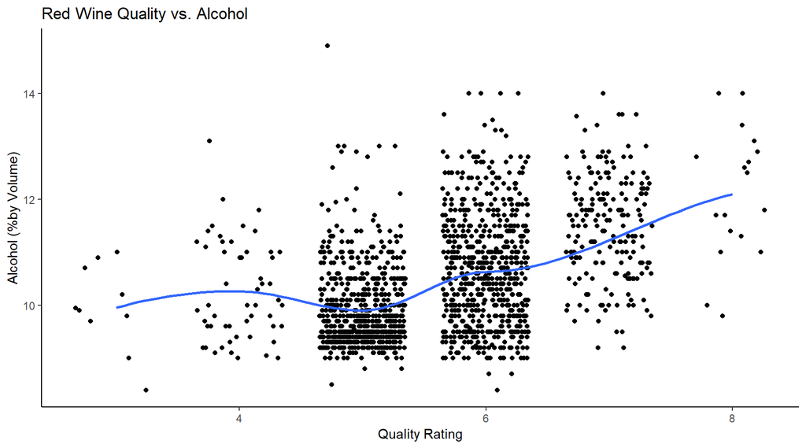

### Description One

My initial investigation into the data set was to find the variables that most affect the quality rating of wine, in part, this is the answer to my question. The correlation between the two variables is positive and moderate at 0.5, of all the other variables, this one shows the highest effect on quality. From the above plot it can be seen that the saturation of points is not at such low alcohol percentages for higher quality wines.

### Plot Two

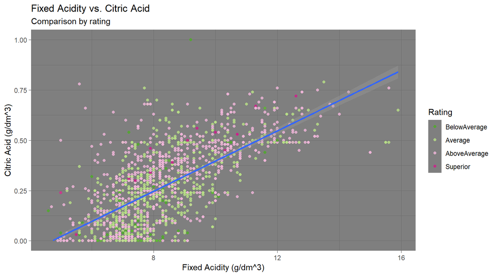

### Description Two

While the relationship between fixed acidity vs. citric acid was not the focus of the above exploration, I think that it is one of the more importatant relationships observed. First of all, the distribution of rating seems to be distributed overall across the plot, with no clusters, it’s difficult to see any specific relationship with rating. The main reason though why I include this in the final plots section is because there is a strong correlation of 0.7 between the two variables and a positive linear relationship, meaning that as citric acid increases, so does fixed acidity. I think that for the final model the three acidity variables should be given special treatment, because there is a natural relationship between them that I think could influence the overall significance.

### Plot Three

[figure not shown]

# Reflection

I started out by observing the relationships of the individual variables and then transitioned to bivariate variables. I was surprised to see that there were such low correlations between quality and most of the variables, even though these variables are all a proportion of red wine. Maybe there is extensive co-dependency, some variables account for others, as with fixed acidity and citric acid, and they are skewing the analysis. One of my limitations is that it is difficult to speak to true insights without significant domain knowledge or statistical tests. But as next steps, a regression model should be built, more work needs to be done in identifying outliers, and log scales, such as for pH should also be taken into account.